# CKME 136 - Laptimes at the Nurburgring

It is important to check the nature of these relationships because we are modeling using a Multiple Linear Regression. Torque, Year, Horsepower appear to be linear in nature and negatively correlated with Time. Weight, appear to be linear in nature and positively correlated with Time.

```r
CylindersComparison <- by(allnumeric[,c(2,3,7,8,11:13,16)], allnumeric$Cylinders, summary)
DrivetrainComparison <- by(cleandata[,c(2,6,12,13,18:20,23)], cleandata$Drivetrain, summary)
EngineLayoutComparison <- by(cleandata[,c(2,6,12,13,18:20,23)], cleandata$Engine_Layout, summary)

CylindersComparison
```

```
## allnumeric$Cylinders: 4
##       Year          Weight       Horsepower        Torque        Cylinders
##  Min.   :2015   Min.   :1378   Min.   :227.0   Min.   :258.0   Min.   :4
##  1st Qu.:2015   1st Qu.:1389   1st Qu.:251.0   1st Qu.:262.0   1st Qu.:4
##  Median :2015   Median :1400   Median :275.0   Median :266.0   Median :4
##  Mean   :2015   Mean   :1393   Mean   :269.3   Mean   :272.7   Mean   :4
##  3rd Qu.:2016   3rd Qu.:1401   3rd Qu.:290.5   3rd Qu.:280.0   3rd Qu.:4
##  Max.   :2016   Max.   :1402   Max.   :306.0   Max.   :294.0   Max.   :4
##    Mins2Secs          AWD      MidEngine
##  Min.   :469.2   Min.   :0   Min.   :0
##  1st Qu.:469.9   1st Qu.:0   1st Qu.:0
##  Median :470.6   Median :0   Median :0
##  Mean   :471.4   Mean   :0   Mean   :0
##  3rd Qu.:472.5   3rd Qu.:0   3rd Qu.:0
##  Max.   :474.4   Max.   :0   Max.   :0
## ------------------------------------------------------------
## allnumeric$Cylinders: 6
##       Year          Weight       Horsepower        Torque        Cylinders
##  Min.   :1992   Min.   :1360   Min.   :355.0   Min.   :273.0   Min.   :6
##  1st Qu.:2005   1st Qu.:1396   1st Qu.:422.2   1st Qu.:317.0   1st Qu.:6
##  Median :2010   Median :1497   Median :480.0   Median :438.5   Median :6
##  Mean   :2008   Mean   :1516   Mean   :471.2   Mean   :406.2   Mean   :6
##  3rd Qu.:2012   3rd Qu.:1624   3rd Qu.:508.0   3rd Qu.:465.2   3rd Qu.:6
##  Max.   :2016   Max.   :1740   Max.   :612.0   Max.   :516.0   Max.   :6
##    Mins2Secs          AWD           MidEngine
##  Min.   :428.7   Min.   :0.0000   Min.   :0.00000
##  1st Qu.:447.7   1st Qu.:0.0000   1st Qu.:0.00000
##  Median :456.2   Median :0.0000   Median :0.00000
##  Mean   :456.1   Mean   :0.3333   Mean   :0.04167
##  3rd Qu.:466.1   3rd Qu.:1.0000   3rd Qu.:0.00000
##  Max.   :476.0   Max.   :1.0000   Max.   :1.00000
## ------------------------------------------------------------
## allnumeric$Cylinders: 8
##       Year          Weight       Horsepower        Torque        Cylinders
##  Min.   :2002   Min.   :1414   Min.   :405.0   Min.   :275.0   Min.   :8
##  1st Qu.:2006   1st Qu.:1486   1st Qu.:504.0   1st Qu.:436.0   1st Qu.:8
##  Median :2010   Median :1619   Median :543.0   Median :479.0   Median :8
##  Mean   :2009   Mean   :1641   Mean   :567.0   Mean   :506.6   Mean   :8
##  3rd Qu.:2012   3rd Qu.:1758   3rd Qu.:604.5   3rd Qu.:573.0   3rd Qu.:8
##  Max.   :2017   Max.   :2058   Max.   :875.0   Max.   :944.0   Max.   :8
```

[output cut: 24 more lines]

```
## allnumeric$Cylinders: 12
##       Year          Weight       Horsepower        Torque        Cylinders
##  Min.   :2002   Min.   :1230   Min.   :547.0   Min.   :448.0   Min.   :12
##  1st Qu.:2004   1st Qu.:1480   1st Qu.:612.0   1st Qu.:481.0   1st Qu.:12
##  Median :2006   Median :1746   Median :631.0   Median :487.0   Median :12
##  Mean   :2006   Mean   :1624   Mean   :634.8   Mean   :522.4   Mean   :12
##  3rd Qu.:2009   3rd Qu.:1793   3rd Qu.:661.0   3rd Qu.:553.0   3rd Qu.:12
##  Max.   :2015   Max.   :1870   Max.   :740.0   Max.   :738.0   Max.   :12
##    Mins2Secs          AWD           MidEngine
##  Min.   :419.7   Min.   :0.0000   Min.   :0.0000
##  1st Qu.:445.0   1st Qu.:0.0000   1st Qu.:1.0000
##  Median :460.0   Median :0.0000   Median :1.0000
##  Mean   :454.8   Mean   :0.4615   Mean   :0.8462
##  3rd Qu.:467.0   3rd Qu.:1.0000   3rd Qu.:1.0000
##  Max.   :471.0   Max.   :1.0000   Max.   :1.0000
```

```r
DrivetrainComparison
```

```
## cleandata$Drivetrain: AWD
##       Year          Weight       Horsepower        Torque        Cylinders
##  Min.   :2000   Min.   :1340   Min.   :414.0   Min.   :376.0   Min.   : 6.000
##  1st Qu.:2008   1st Qu.:1610   1st Qu.:508.0   1st Qu.:421.5   1st Qu.: 6.000
##  Median :2009   Median :1720   Median :552.0   Median :479.0   Median : 8.000
##  Mean   :2010   Mean   :1698   Mean   :574.4   Mean   :486.5   Mean   : 8.783
##  3rd Qu.:2011   3rd Qu.:1758   3rd Qu.:631.0   3rd Qu.:509.0   3rd Qu.:11.000
##  Max.   :2017   Max.   :2058   Max.   :875.0   Max.   :944.0   Max.   :12.000
##    Mins2Secs          AWD      MidEngine
##  Min.   :417.0   Min.   :1   Min.   :0.0000
##  1st Qu.:445.9   1st Qu.:1   1st Qu.:0.0000
##  Median :458.0   Median :1   Median :1.0000
##  Mean   :455.2   Mean   :1   Mean   :0.5217
##  3rd Qu.:467.0   3rd Qu.:1   3rd Qu.:1.0000
##  Max.   :476.0   Max.   :1   Max.   :1.0000
## ------------------------------------------------------------
## cleandata$Drivetrain: FWD
##       Year          Weight       Horsepower        Torque        Cylinders
##  Min.   :2015   Min.   :1378   Min.   :227.0   Min.   :258.0   Min.   :4
##  1st Qu.:2015   1st Qu.:1389   1st Qu.:251.0   1st Qu.:262.0   1st Qu.:4
##  Median :2015   Median :1400   Median :275.0   Median :266.0   Median :4
##  Mean   :2015   Mean   :1393   Mean   :269.3   Mean   :272.7   Mean   :4
##  3rd Qu.:2016   3rd Qu.:1401   3rd Qu.:290.5   3rd Qu.:280.0   3rd Qu.:4
##  Max.   :2016   Max.   :1402   Max.   :306.0   Max.   :294.0   Max.   :4
##    Mins2Secs          AWD      MidEngine
##  Min.   :469.2   Min.   :0   Min.   :0
##  1st Qu.:469.9   1st Qu.:0   1st Qu.:0
##  Median :470.6   Median :0   Median :0
##  Mean   :471.4   Mean   :0   Mean   :0
##  3rd Qu.:472.5   3rd Qu.:0   3rd Qu.:0
##  Max.   :474.4   Max.   :0   Max.   :0
## ------------------------------------------------------------
## cleandata$Drivetrain: RWD
##       Year          Weight       Horsepower        Torque        Cylinders
##  Min.   :1992   Min.   :1230   Min.   :355.0   Min.   :273.0   Min.   : 6.000
##  1st Qu.:2004   1st Qu.:1419   1st Qu.:488.0   1st Qu.:356.0   1st Qu.: 6.000
##  Median :2009   Median :1497   Median :542.0   Median :465.0   Median : 8.000
##  Mean   :2008   Mean   :1533   Mean   :535.5   Mean   :456.2   Mean   : 8.109
##  3rd Qu.:2011   3rd Qu.:1628   3rd Qu.:597.0   3rd Qu.:534.5   3rd Qu.: 8.000
##  Max.   :2017   Max.   :1870   Max.   :806.0   Max.   :738.0   Max.   :12.000
##    Mins2Secs          AWD      MidEngine
##  Min.   :432.1   Min.   :0   Min.   :0.0000
##  1st Qu.:448.4   1st Qu.:0   1st Qu.:0.0000
##  Median :459.0   Median :0   Median :0.0000
##  Mean   :458.1   Mean   :0   Mean   :0.3091
##  3rd Qu.:467.5   3rd Qu.:0   3rd Qu.:1.0000
##  Max.   :476.0   Max.   :0   Max.   :1.0000
```

```r
EngineLayoutComparison
```

```
## cleandata$Engine_Layout: Front-Engine
##       Year          Weight       Horsepower        Torque        Cylinders
##  Min.   :2002   Min.   :1378   Min.   :227.0   Min.   :258.0   Min.   : 4.000
##  1st Qu.:2009   1st Qu.:1524   1st Qu.:482.5   1st Qu.:417.5   1st Qu.: 6.000
##  Median :2011   Median :1664   Median :510.0   Median :463.0   Median : 8.000
##  Mean   :2011   Mean   :1653   Mean   :512.7   Mean   :461.5   Mean   : 7.538
##  3rd Qu.:2015   3rd Qu.:1758   3rd Qu.:568.5   3rd Qu.:509.0   3rd Qu.: 8.000
##  Max.   :2017   Max.   :2058   Max.   :671.0   Max.   :738.0   Max.   :12.000
##    Mins2Secs          AWD           MidEngine
##  Min.   :428.7   Min.   :0.0000   Min.   :0
##  1st Qu.:448.8   1st Qu.:0.0000   1st Qu.:0
##  Median :460.0   Median :0.0000   Median :0
##  Mean   :458.7   Mean   :0.2051   Mean   :0
##  3rd Qu.:470.8   3rd Qu.:0.0000   3rd Qu.:0
##  Max.   :476.0   Max.   :1.0000   Max.   :0
## ------------------------------------------------------------
## cleandata$Engine_Layout: Mid-Engine
##       Year          Weight       Horsepower        Torque        Cylinders
##  Min.   :1992   Min.   :1230   Min.   :419.0   Min.   :275.0   Min.   : 6.000
##  1st Qu.:2004   1st Qu.:1429   1st Qu.:542.0   1st Qu.:398.0   1st Qu.: 8.000
##  Median :2006   Median :1517   Median :592.0   Median :479.0   Median :10.000
##  Mean   :2006   Mean   :1530   Mean   :605.9   Mean   :485.9   Mean   : 9.931
##  3rd Qu.:2009   3rd Qu.:1620   3rd Qu.:651.0   3rd Qu.:553.0   3rd Qu.:12.000
##  Max.   :2015   Max.   :1853   Max.   :875.0   Max.   :944.0   Max.   :12.000
##    Mins2Secs          AWD           MidEngine
##  Min.   :417.0   Min.   :0.0000   Min.   :1
##  1st Qu.:448.0   1st Qu.:0.0000   1st Qu.:1
##  Median :458.0   Median :0.0000   Median :1
##  Mean   :455.9   Mean   :0.4138   Mean   :1
##  3rd Qu.:466.4   3rd Qu.:1.0000   3rd Qu.:1
##  Max.   :476.0   Max.   :1.0000   Max.   :1
## ------------------------------------------------------------
## cleandata$Engine_Layout: Rear-Engine
##       Year          Weight       Horsepower        Torque        Cylinders
##  Min.   :2000   Min.   :1360   Min.   :376.0   Min.   :284.0   Min.   :6
##  1st Qu.:2003   1st Qu.:1380   1st Qu.:409.0   1st Qu.:299.0   1st Qu.:6
##  Median :2009   Median :1400   Median :444.0   Median :339.0   Median :6
##  Mean   :2007   Mean   :1438   Mean   :454.5   Mean   :385.7   Mean   :6
##  3rd Qu.:2010   3rd Qu.:1438   3rd Qu.:493.0   3rd Qu.:472.0   3rd Qu.:6
##  Max.   :2011   Max.   :1620   Max.   :612.0   Max.   :516.0   Max.   :6
##    Mins2Secs        AWD           MidEngine
##  Min.   :438   Min.   :0.0000   Min.   :0
##  1st Qu.:452   1st Qu.:0.0000   1st Qu.:0
##  Median :460   Median :0.0000   Median :0
##  Mean   :459   Mean   :0.2308   Mean   :0
##  3rd Qu.:466   3rd Qu.:0.0000   3rd Qu.:0
##  Max.   :476   Max.   :1.0000   Max.   :0
```

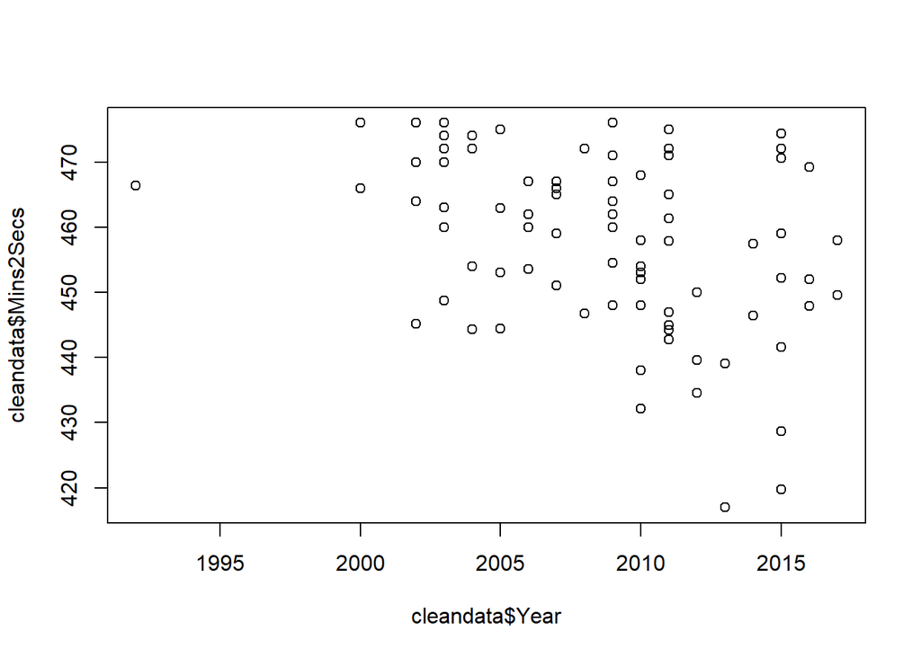

```r
plot(cleandata$Year, cleandata$Mins2Secs)
```

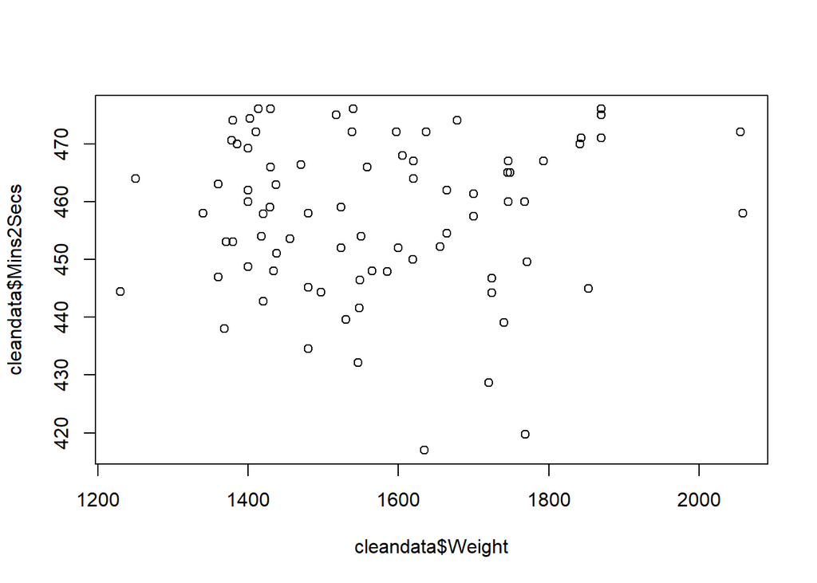

```r
plot(cleandata$Weight, cleandata$Mins2Secs)
```

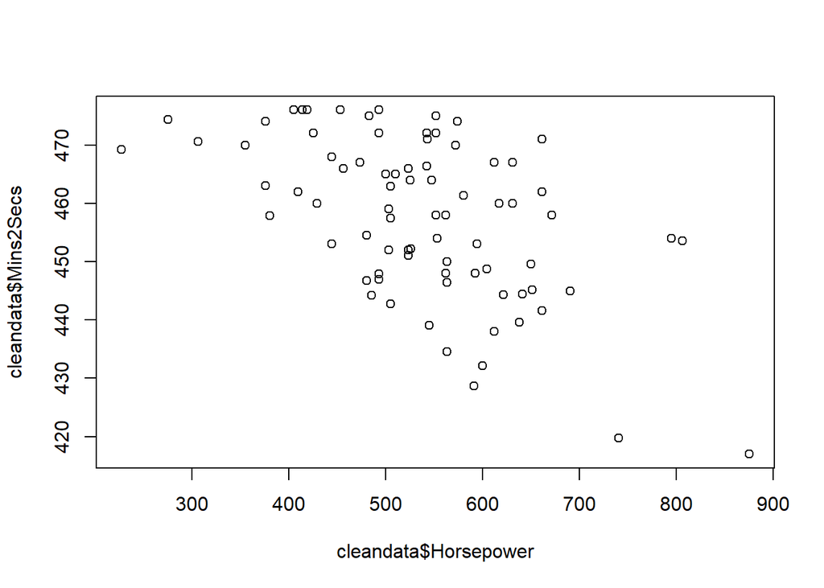

```r
plot(cleandata$Horsepower, cleandata$Mins2Secs)
```

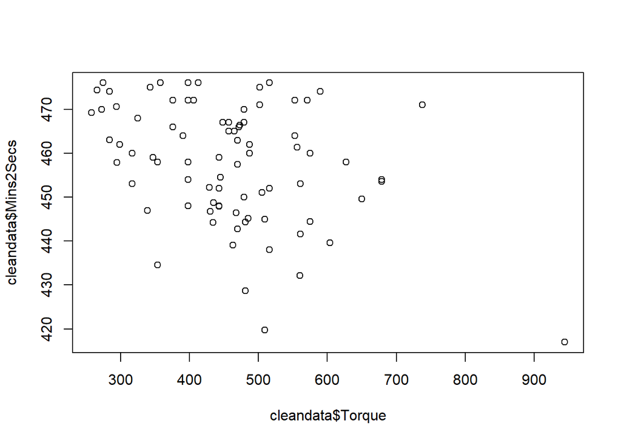

```r
plot(cleandata$Torque, cleandata$Mins2Secs)
```

After experimenting with and without scaling, I thought it best to scale Years, Weight, Horsepower, Torque, and Cylinders. The previous models would have to compensate far too much to accommodate Year+Weight (1000s), HP+Torque (100s) and then Cylinders (4 to 12).

```r
finalvars[c(1:5)] <- lapply(finalvars[c(1:5)], function(x) c(scale(x)))
```

Two initial models are to be explored here: Basic MLR w/ final vars (1), Modified MLR Model w/ final vars and clusters (2)

1. Most vars behaving in the expected manner, with the exception of Mid-Engine, Cylinders, Torque (positive instead of negative)
2. Most vars behaving in the expected manner, with the exception of Mid-Engine, Cylinders (positive instead of negative)

We created different clusters for different archetypes of cars and determined that the optimal number of clusters is four, this was determined using the NbClust package.

Previously, before scaling, the clusters seemed to focus on all the elements of the car. However, after scaling, it seems it have assigned cluster groups primarily based off of time. This actually makes a lot of sense intuitively, primarily because companies would use the laptime to benchmark their cars!

```r
finalvarsmodel <- lm(Mins2Secs~Year+Weight+Horsepower+Torque+Cylinders+AWD+MidEngine, finalvars)
summary(finalvarsmodel)
```

```
##
## Call:
## lm(formula = Mins2Secs ~ Year + Weight + Horsepower + Torque +
##     Cylinders + AWD + MidEngine, data = finalvars)
##
## Residuals:
##      Min       1Q   Median       3Q      Max
## -18.3724  -4.8288  -0.0777   5.3966  21.6076
##
## Coefficients:
##             Estimate Std. Error t value Pr(>|t|)
## (Intercept)  456.389      1.459 312.782  < 2e-16 ***
## Year          -4.812      1.104  -4.358 4.23e-05 ***
## Weight         6.933      1.315   5.274 1.31e-06 ***
## Horsepower   -15.171      2.354  -6.445 1.09e-08 ***
## Torque         4.289      1.947   2.203  0.03076 *
## Cylinders      1.730      1.464   1.182  0.24122
## AWD           -5.932      2.514  -2.359  0.02099 *
## MidEngine      8.445      3.168   2.665  0.00947 **
## ---
## Signif. codes:  0 '***' 0.001 '**' 0.01 '*' 0.05 '.' 0.1 ' ' 1
##
## Residual standard error: 8.48 on 73 degrees of freedom
## Multiple R-squared:  0.6398, Adjusted R-squared:  0.6053
## F-statistic: 18.52 on 7 and 73 DF,  p-value: 6.03e-14
```

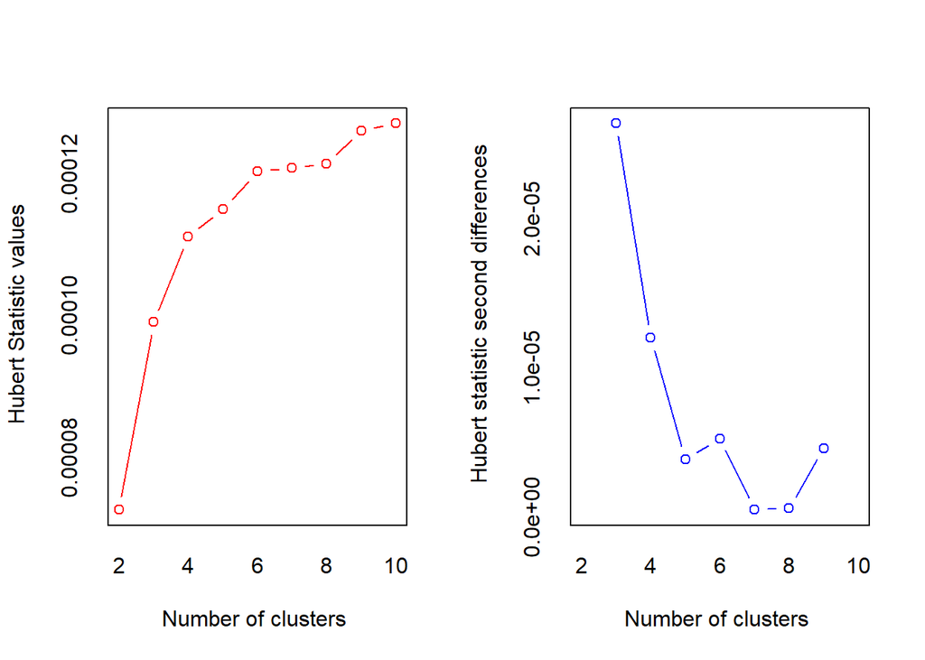

```
## *** : The Hubert index is a graphical method of determining the number of clusters.
##                 In the plot of Hubert index, we seek a significant knee that corresponds to a
##                 significant increase of the value of the measure i.e the significant peak in Hubert
##                 index second differences plot.
##
```

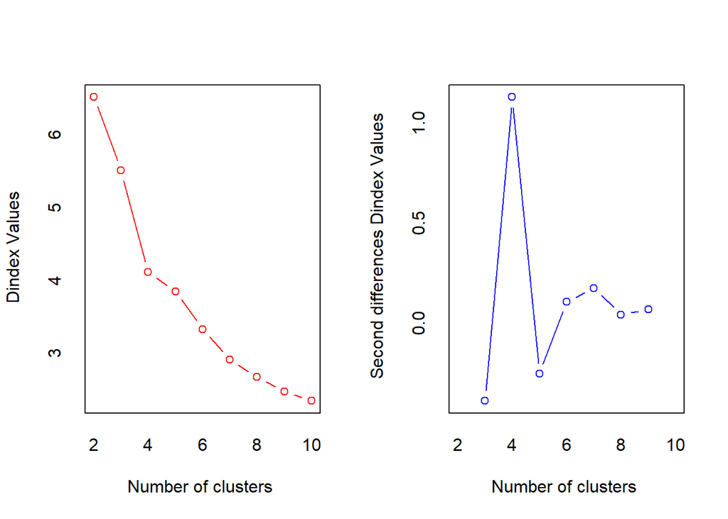

```
## *** : The D index is a graphical method of determining the number of clusters.
##                 In the plot of D index, we seek a significant knee (the significant peak in Dindex
##                 second differences plot) that corresponds to a significant increase of the value of
##                 the measure.
##
## * Among all indices:
## * 4 proposed 2 as the best number of clusters
## * 5 proposed 3 as the best number of clusters
## * 6 proposed 4 as the best number of clusters
## * 1 proposed 5 as the best number of clusters
## * 2 proposed 8 as the best number of clusters
## * 2 proposed 9 as the best number of clusters
## * 2 proposed 10 as the best number of clusters
##
##                    ***** Conclusion *****
##
## * According to the majority rule, the best number of clusters is  4
##
##
```

```r
library(NbClust)
res.nbclust <- NbClust(finalvars, distance = "euclidean", min.nc = 2, max.nc = 10, method = "complete", index ="all")
```

```r
km4f <- kmeans(finalvars, centers = 4, nstart = 100)
km4f
```

```
## K-means clustering with 4 clusters of sizes 25, 22, 5, 29
##
## Cluster means:
##         Year      Weight  Horsepower     Torque   Cylinders Mins2Secs       AWD
## 1 -0.2638672  0.00947828 -0.07779499 -0.1606214  0.15025649  462.2400 0.3200000
## 2 -0.2228655  0.22599187 -0.70004604 -0.3716233 -0.23172673  472.8273 0.2272727
## 3  0.8970865  0.30866475  1.24062162  0.9512855  0.47625941  426.4200 0.6000000
## 4  0.2418720 -0.23283110  0.38423377  0.2563731 -0.03585246  447.7828 0.2413793
##   MidEngine
## 1 0.3600000
## 2 0.2727273
## 3 0.4000000
## 4 0.4137931
##
## Clustering vector:
##  [1] 3 3 3 3 3 4 4 4 4 4 4 4 4 4 4 4 4 4 4 4 4 4 4 4 4 4 4 4 4 4 4 4 4 4 1 1 1 1
## [39] 1 1 1 1 1 1 1 1 1 1 1 1 1 1 1 1 1 1 1 1 1 2 2 2 2 2 2 2 2 2 2 2 2 2 2 2 2 2
## [77] 2 2 2 2 2
##
## Within cluster sum of squares by cluster:
## [1] 385.9082 259.0051 267.5991 754.9835
##  (between_SS / total_SS =  88.9 %)
##
## Available components:
##
## [1] "cluster"      "centers"      "totss"        "withinss"     "tot.withinss"
## [6] "betweenss"    "size"         "iter"         "ifault"
```

```r
finalvarscluster <- finalvars
finalvarscluster$cluster1 <- km4f$cluster
finalvarscluster$cluster2 <- 0
finalvarscluster$cluster3 <- 0
finalvarscluster$cluster3[which(finalvarscluster$cluster1 == 3)] <- 1
finalvarscluster$cluster2[which(finalvarscluster$cluster1 == 2)] <- 1
finalvarscluster$cluster1[which(finalvarscluster$cluster1 != 1)] <- 0

finalvarsclustermodel <- lm(Mins2Secs~Year+Weight+Horsepower+Torque+Cylinders+AWD+MidEngine+cluster1+cluster2+cluster3, finalvarscluster)
summary(finalvarsclustermodel)
```

```
##
## Call:
## lm(formula = Mins2Secs ~ Year + Weight + Horsepower + Torque +
##     Cylinders + AWD + MidEngine + cluster1 + cluster2 + cluster3,
##     data = finalvarscluster)
##
## Residuals:
##     Min      1Q  Median      3Q     Max
## -8.5164 -2.6299 -0.1545  2.2524  8.1699
##
## Coefficients:
##               Estimate Std. Error t value Pr(>|t|)
## (Intercept) 449.259695   0.960644 467.665  < 2e-16 ***
## Year         -1.731303   0.545381  -3.174  0.00223 **
## Weight        1.098891   0.713520   1.540  0.12805
## Horsepower   -1.695106   1.402632  -1.209  0.23091
## Torque       -0.002859   0.956894  -0.003  0.99762
## Cylinders     0.274932   0.689791   0.399  0.69142
## AWD          -0.711202   1.219501  -0.583  0.56164
## MidEngine     0.075521   1.584370   0.048  0.96212
## cluster1     12.539813   1.228372  10.208 1.68e-15 ***
## cluster2     21.950425   1.623239  13.523  < 2e-16 ***
## cluster3    -19.254476   2.057078  -9.360 5.80e-14 ***
## ---
## Signif. codes:  0 '***' 0.001 '**' 0.01 '*' 0.05 '.' 0.1 ' ' 1
##
## Residual standard error: 3.914 on 70 degrees of freedom
## Multiple R-squared:  0.9264, Adjusted R-squared:  0.9159
## F-statistic: 88.13 on 10 and 70 DF,  p-value: < 2.2e-16
```

Visualizing the models: 1A) MLR using finalvars 1B) MLR using finalvarscluster

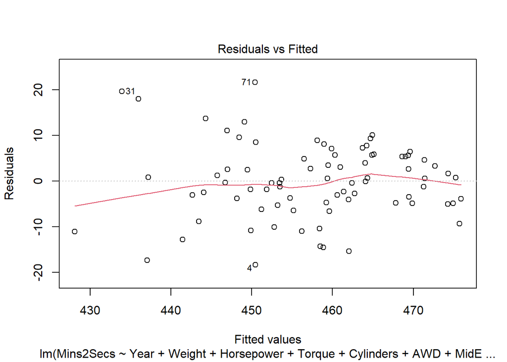

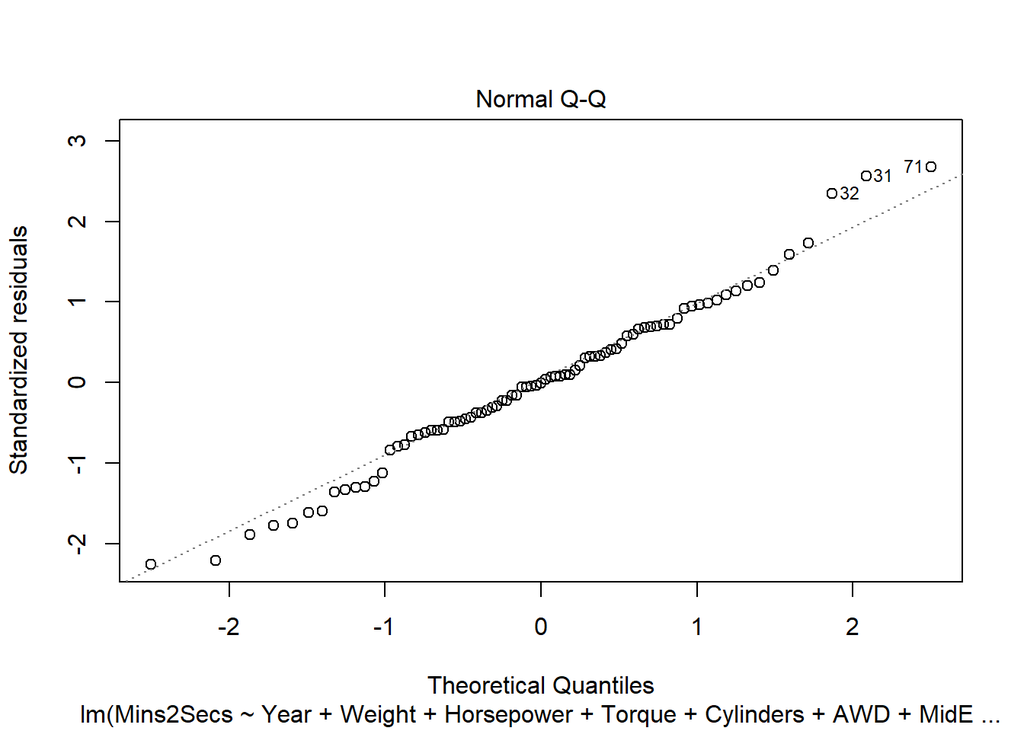

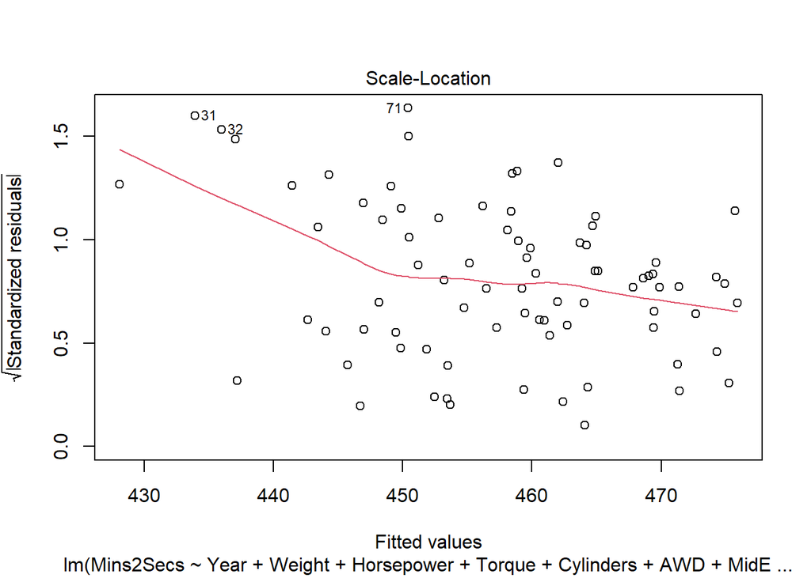

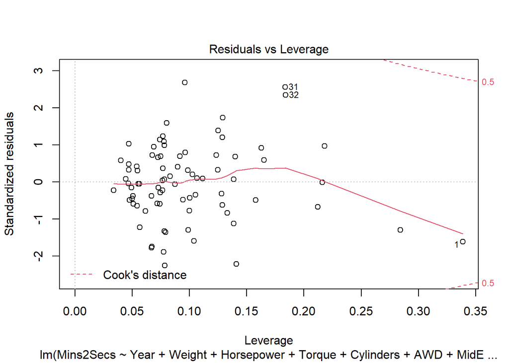

```r
plot(finalvarsmodel)
```

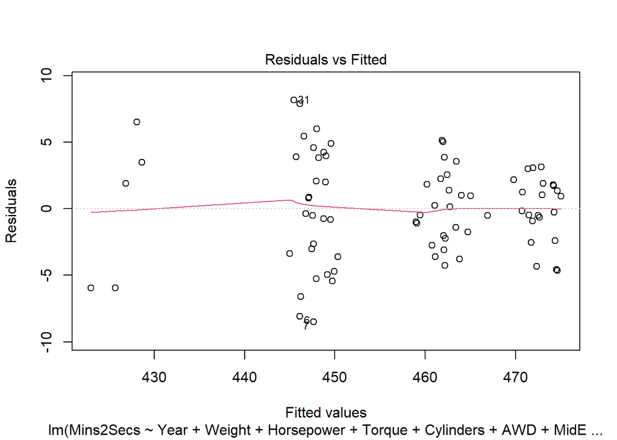

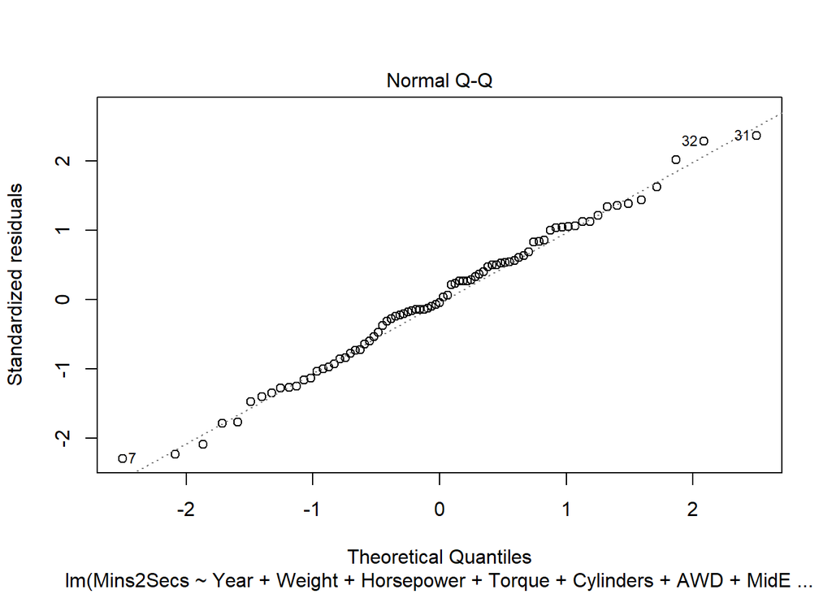

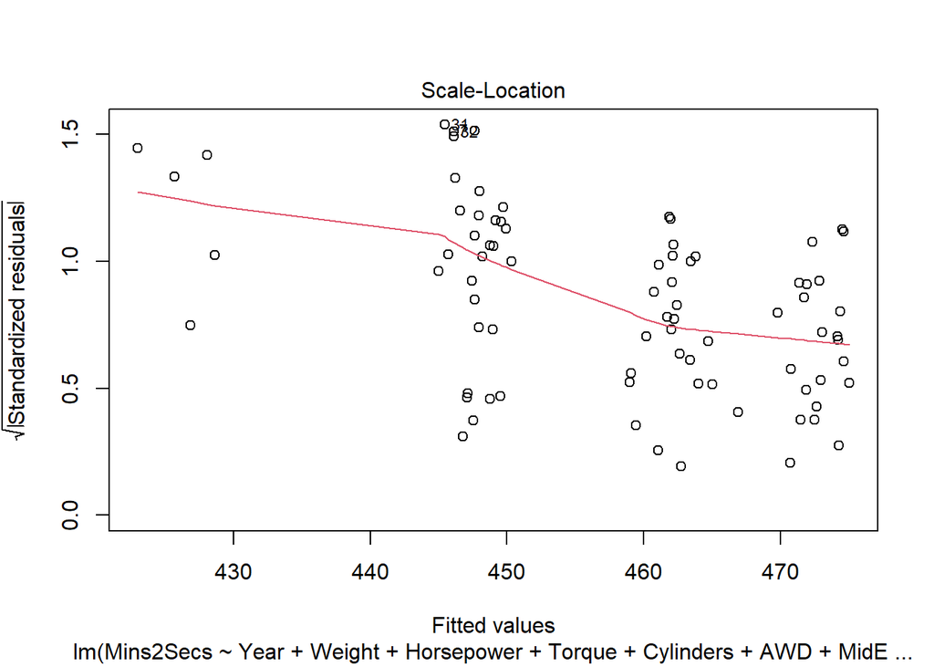

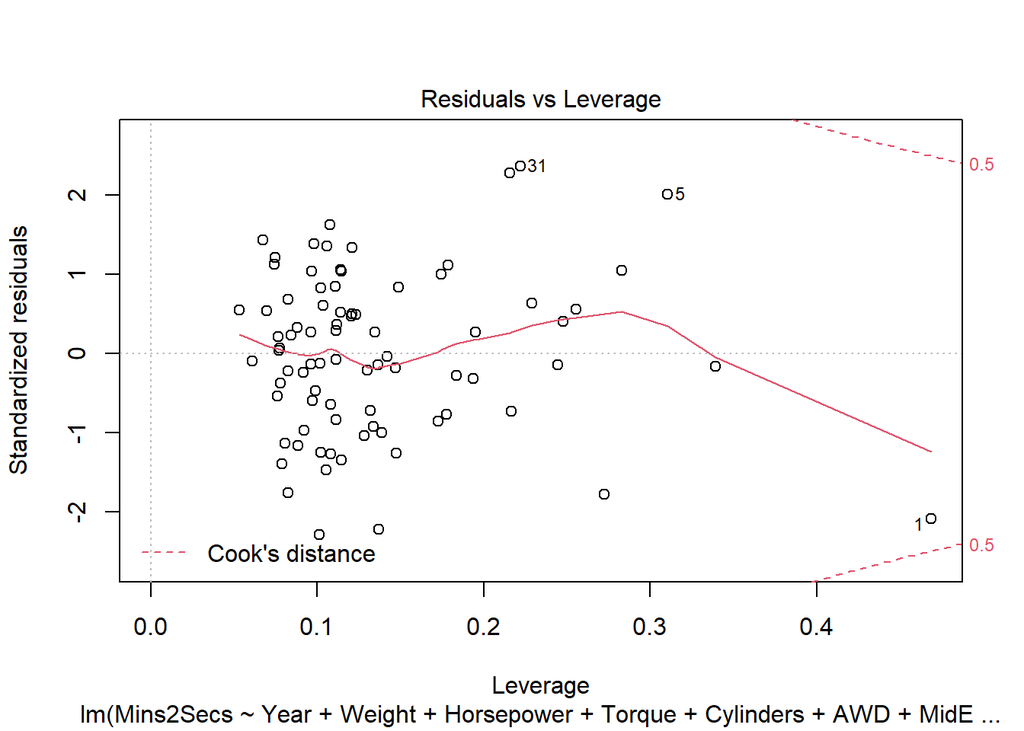

```r
plot(finalvarsclustermodel)
```

Model Performance for 1A) MLR using finalvars. We employed R-squared (adjusted R-squared), RMSE, Mean Absolute Error, Akaikes Information Criterion (AIC).

```r
summary(finalvarsmodel) #R-squared: 0.6398, 0.6053 (adjusted)
```

```
##
## Call:
## lm(formula = Mins2Secs ~ Year + Weight + Horsepower + Torque +
##     Cylinders + AWD + MidEngine, data = finalvars)
##
## Residuals:
##      Min       1Q   Median       3Q      Max
## -18.3724  -4.8288  -0.0777   5.3966  21.6076
##
## Coefficients:
##             Estimate Std. Error t value Pr(>|t|)
## (Intercept)  456.389      1.459 312.782  < 2e-16 ***
## Year          -4.812      1.104  -4.358 4.23e-05 ***
## Weight         6.933      1.315   5.274 1.31e-06 ***
## Horsepower   -15.171      2.354  -6.445 1.09e-08 ***
## Torque         4.289      1.947   2.203  0.03076 *
## Cylinders      1.730      1.464   1.182  0.24122
## AWD           -5.932      2.514  -2.359  0.02099 *
## MidEngine      8.445      3.168   2.665  0.00947 **
## ---
## Signif. codes:  0 '***' 0.001 '**' 0.01 '*' 0.05 '.' 0.1 ' ' 1
##
## Residual standard error: 8.48 on 73 degrees of freedom
## Multiple R-squared:  0.6398, Adjusted R-squared:  0.6053
## F-statistic: 18.52 on 7 and 73 DF,  p-value: 6.03e-14
```

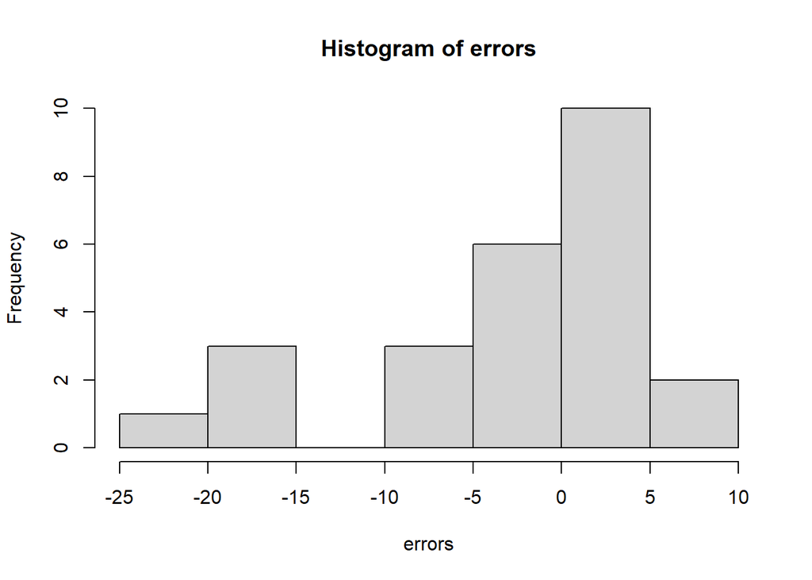

```r
rn_train <- sample(nrow(finalvars), floor(nrow(finalvars)*0.7))
train <- finalvars[rn_train,]
test <- finalvars[-rn_train,]

model_mlr <- lm(Mins2Secs~Year+Weight+Horsepower+Torque+Cylinders+AWD+MidEngine, data=train)
prediction <- predict(model_mlr, interval="prediction", newdata =test)

errors <- prediction[,"fit"] - test$Mins2Secs
hist(errors)
```

```r
rmse <- sqrt(sum((errors)^2)/nrow(test))
rel_change <- abs(errors) / test$Mins2Secs
pred5 <- table(rel_change<0.05)["TRUE"] / nrow(test)
table(rel_change)
```

```
## rel_change
## 0.000229621898041051 0.000753588911067001   0.0013649089464439
##                    1                    1                    1
##  0.00152013327019014  0.00154463138235959  0.00258441187722705
##                    1                    1                    1
##  0.00428551564316364  0.00460689870152789    0.005435189212681
##                    1                    1                    1
##  0.00594351164181867  0.00640204164688584  0.00676446293729502
##                    1                    1                    1
##  0.00719789611597913   0.0086684048586768   0.0101077090717935
##                    1                    1                    1
##   0.0105420279481677   0.0109980403058088   0.0116535368279385
##                    1                    1                    1
##   0.0125713816618182   0.0205072261505921   0.0206799061641102
##                    1                    1                    1
##   0.0330217787087659   0.0358552849761549   0.0400215208267259
##                    1                    1                    1
##   0.0501160208572439
##                    1
```

```r
paste("RMSE:", rmse) #11.56290 (for this instance)
```

```
## [1] "RMSE: 8.36150384187841"
```

```r
paste("PRED(5):", pred5) #92% of cases with less than 5% error (for this instance)
```

```
## [1] "PRED(5): 0.96"
```

```r
#install.packages("caret")
library(caret)
MAE(prediction, test$Mins2Secs) #14.731 (for this instance)
```

```
## [1] 14.96942
```

```r
AIC(model_mlr) #404.9688 (for this instance)
```

```
## [1] 414.6986
```

```r
BIC(model_mlr) #425.5252 (for this instance)
```

```
## [1] 432.9268
```

Model Performance for 1B) MLR using finalvarscluster. We employed R-squared (adjusted R-squared), RMSE, Mean Absolute Error, Akaikes Information Criterion (AIC).

```r
summary(finalvarsclustermodel) #R-squared: 0.9264, 0.9159 (adjusted)
```

```
##
## Call:
## lm(formula = Mins2Secs ~ Year + Weight + Horsepower + Torque +
##     Cylinders + AWD + MidEngine + cluster1 + cluster2 + cluster3,
##     data = finalvarscluster)
##
## Residuals:
##     Min      1Q  Median      3Q     Max
## -8.5164 -2.6299 -0.1545  2.2524  8.1699
##
## Coefficients:
##               Estimate Std. Error t value Pr(>|t|)
## (Intercept) 449.259695   0.960644 467.665  < 2e-16 ***
## Year         -1.731303   0.545381  -3.174  0.00223 **
## Weight        1.098891   0.713520   1.540  0.12805
## Horsepower   -1.695106   1.402632  -1.209  0.23091
## Torque       -0.002859   0.956894  -0.003  0.99762
## Cylinders     0.274932   0.689791   0.399  0.69142
## AWD          -0.711202   1.219501  -0.583  0.56164
## MidEngine     0.075521   1.584370   0.048  0.96212
## cluster1     12.539813   1.228372  10.208 1.68e-15 ***
## cluster2     21.950425   1.623239  13.523  < 2e-16 ***
## cluster3    -19.254476   2.057078  -9.360 5.80e-14 ***
## ---
## Signif. codes:  0 '***' 0.001 '**' 0.01 '*' 0.05 '.' 0.1 ' ' 1
##
## Residual standard error: 3.914 on 70 degrees of freedom
## Multiple R-squared:  0.9264, Adjusted R-squared:  0.9159
## F-statistic: 88.13 on 10 and 70 DF,  p-value: < 2.2e-16
```

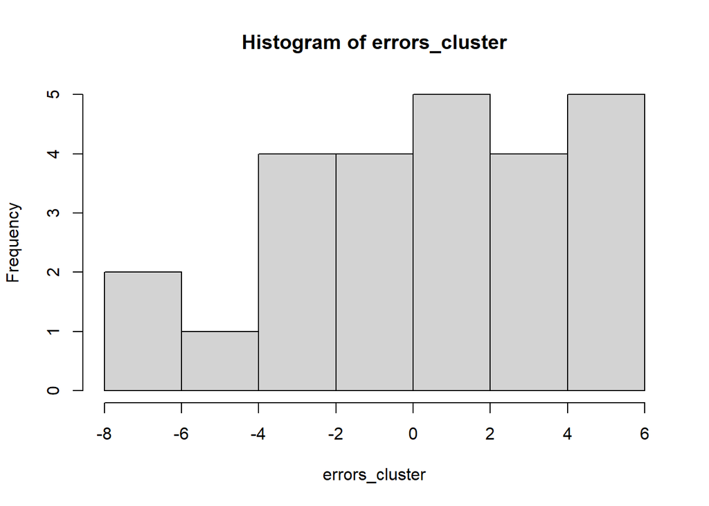

```r
rn_train_cluster <- sample(nrow(finalvarscluster), floor(nrow(finalvarscluster)*0.7))
traincluster <- finalvarscluster[rn_train_cluster,]
testcluster <- finalvarscluster[-rn_train_cluster,]


model_mlr_cluster <- lm(Mins2Secs~Year+Weight+Horsepower+Torque+Cylinders+AWD+MidEngine+cluster1+cluster2+cluster3, data=traincluster)
prediction_cluster <- predict(model_mlr_cluster, interval="prediction", newdata =testcluster)

errors_cluster <- prediction_cluster[,"fit"] - testcluster$Mins2Secs
hist(errors_cluster)
```

```r
rmse_cluster <- sqrt(sum((errors_cluster)^2)/nrow(testcluster))
rel_change_cluster <- abs(errors_cluster) / testcluster$Mins2Secs
pred5clust <- table(rel_change<0.05)["TRUE"] / nrow(testcluster)
table(rel_change_cluster)
```

```
## rel_change_cluster
## 0.00100406178504693 0.00110165094537383 0.00269841071762754  0.0028269788879162
##                   1                   1                   1                   1
## 0.00308549704467977 0.00364273654713924 0.00404816272905189 0.00416770131427405
##                   1                   1                   1                   1
## 0.00420059271081318 0.00543506717048576 0.00567458735395504 0.00570693458250477
##                   1                   1                   1                   1
## 0.00634048411738835 0.00703327487220283  0.0082100789704893 0.00838064336317688
##                   1                   1                   1                   1
## 0.00866792651457804  0.0096317524387698  0.0102928462637547     0.0106085902386
##                   1                   1                   1                   1
##  0.0112502601804402  0.0126150196248624  0.0131508652818677  0.0142188332302527
##                   1                   1                   1                   1
##  0.0183617460692643
##                   1
```

```r
paste("RMSE:", rmse_cluster) #6.0049 (for this instance)
```

```
## [1] "RMSE: 3.80431967850262"
```

```r
paste("PRED(5):", pred5clust) #92% of cases with less than 5% error (for this instance)
```

```
## [1] "PRED(5): 0.96"
```

```r
MAE(prediction_cluster, testcluster$Mins2Secs) #6.907 (for this instance)
```

```
## [1] 7.20856
```

```r
AIC(model_mlr_cluster) #317.5095 (for this instance)
```

```
## [1] 327.594
```

```r
BIC(model_mlr_cluster) #349.9414 (for this instance)
```

```
## [1] 351.8983
```